# Binomial Distributions Pt. I: Simulation, PDF, CDF

October 1, 2021

# Empirical, simulated, and ideal data

All distributions (binomial, normal etc.) that we cover in this course are **ideal** distributions. Real data are very rarely distributed in *exactly* the same way. Still, as long as real data are distributed in *almost* the same way, it is useful to assume that they are well described by some ideal distribution. This allows us to use the same set of mathematical tools for every set of similarly distributed data.

Here, we will compare three distributions:

1. We will collect **real** data where we will measure the number of successes in a fixed number of trials.
2. We will **simulate** a random sample of binomially distributed data using R.
3. We will compare both to an **ideal** binomial distribution constructed using R.

## Collect empirical data of the `N(successes)/N(trials)` variety

Each of you will get a 2-sided and a 3-sided fidget spinner. Spin each spinner **12 times**. Each time, stop it by hand and determine whether **pink** or **other than pink** side came on top. Keep a tally (you may use [this website](https://tallycount.app/)). We will refer to each of the 12 spins as **trials**, and the number of times the pink came on top in 12 trials will be considered a single **observation**.

Let each of us record one observation of the number of successes in 12 trials. Each person needs to submit 1 observation for the 2-sided spinner and 1 observation for the 3-sided spinner.

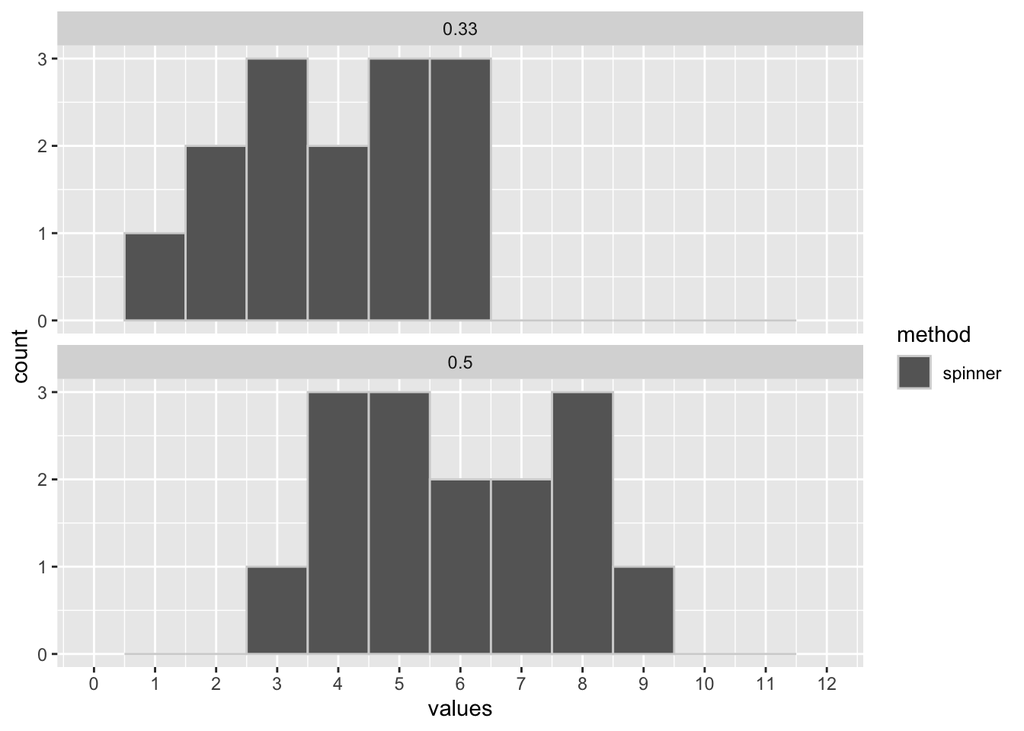

```r
# record all observations for the 2-sided spinner
spinner2 <- c(8, 8, 4, 5, 9, 5, 5, 6, 7, 8, 6, 7, 4, 4, 3)

# record all observations for the 3-sided spinner
spinner3 <- c(3, 5, 6, 3, 1, 6, 2, 5, 6, 2, 4, 5, 3, 4)

# arrange the data in a data.frame (long format)
bino_data <- data.frame("method" = "spinner",
                        "theoretical_probability" = c( rep(0.5, length(spinner2) ),
                                                       rep(0.33, length(spinner3) ) ),
                        "values" = c(spinner2, spinner3))

# plot the frequencies
ggplot(data = bino_data,
       mapping = aes(x = values,
                     fill = method)) +
  geom_histogram(position = position_dodge(0.7),
                 breaks = seq(from = -0.5, to = 12.5, by = 1),
                 col = "lightgrey") +
  scale_fill_manual(values = "grey40") +
  scale_x_continuous(breaks = 0:12,
                     labels = 0:12,
                     limits = c(0,12)) +
  facet_wrap(~theoretical_probability,
             ncol = 1)
```

## Simulate a random sample of binomially distributed data with the same parameters

R allows you to simulate data randomly sampled from a distribution with given parameters. For this, we use “r” (“random sample”) functions from the “d/p/q/r” family. Since we are working with binomial data, we will use the function `rbinom()`.

```r
# simulate performing 15 observations of the number of successes in 12 trials if the probability of success = 0.5
simulated0.5 <- rbinom(n = 15,
                       size = 12,
                       prob = 0.5)
simulated0.5
```

```
##  [1] 3 8 4 6 8 5 9 4 6 6 6 5 6 5 4
```

```r
# simulate performing 15 observations of the number of successes in 12 trials if the probability of success = 1/3
simulated0.33 <- rbinom(n = 15,
                        size = 12,
                        prob = 1/3)
simulated0.33
```

```
##  [1] 6 4 2 3 7 3 6 0 4 4 4 3 3 5 4
```

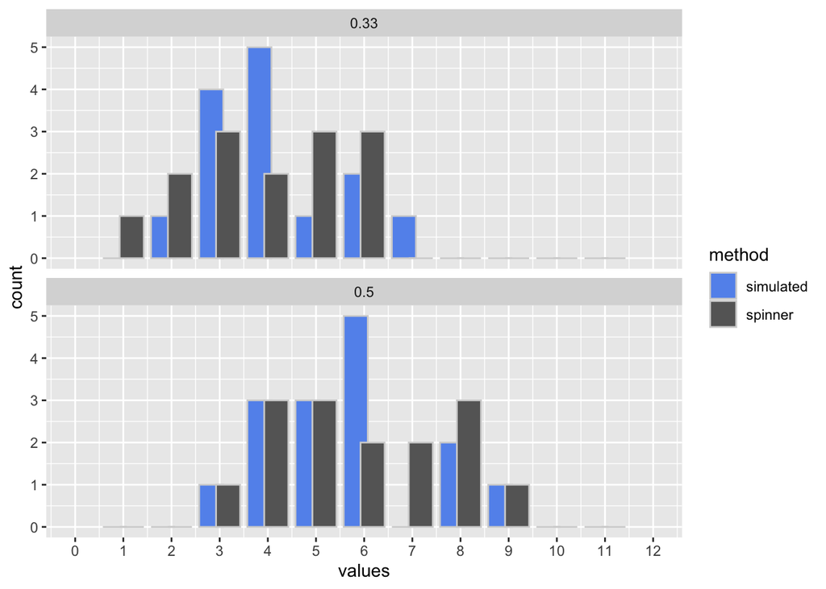

```r
# add to bino_data
new_bino_data <- data.frame("method" = "simulated",
                            "theoretical_probability" = c( rep(0.5, length(simulated0.5) ),
                                                           rep(0.33, length(simulated0.33) ) ),
                            "values" = c( simulated0.5, simulated0.33 ))

bino_data <- rbind(bino_data, new_bino_data)

# plot all frequencies
ggplot(data = bino_data,
       mapping = aes(x = values,
                     fill = method)) +
  geom_histogram(position = position_dodge(0.7),
                 breaks = seq(from = -0.5, to = 12.5, by = 1),
                 col = "lightgrey") +
  scale_fill_manual(values = c("cornflowerblue", "grey40")) +
  scale_x_continuous(breaks = 0:12,
                     labels = 0:12,
                     limits = c(0,12)) +
  facet_wrap(~theoretical_probability,
             ncol = 1)
```

## Generate the frequencies of an ideal binomial distribution with the same parameters

We can use a sister function of `rbinom()` from the “d/p/q/r” family called `dbinom()` to generate a PDF of an ideal binomial distribution with the same parameters. The output will be a vector of probabilities for each observation (e.g. probability to observe 0 successes in 12 trials, 1 success, 2 successes etc.) on a scale of 0 to 1. We will need to convert these observation probabilities into real numbers of observations since we are performing a finite number of observations.

```r
# simulate an ideal binomial distribution of the number of successes in 12 trials if the probability of success = 0.5
n_successes_vector <- 0:12

dbinom0.5 <- dbinom(x = n_successes_vector,
                    size = 12,
                    prob = 0.5)
dbinom0.5
```

```
##  [1] 0.0002441406 0.0029296875 0.0161132813 0.0537109375 0.1208496094
##  [6] 0.1933593750 0.2255859375 0.1933593750 0.1208496094 0.0537109375
## [11] 0.0161132813 0.0029296875 0.0002441406
```

```r
# simulate an ideal binomial distribution of the number of successes in 12 trials if the probability of success = 1/3
dbinom0.33 <- dbinom(x = n_successes_vector,
                     size = 12,
                     prob = 1/3)
dbinom0.33
```

```
##  [1] 7.707347e-03 4.624408e-02 1.271712e-01 2.119520e-01 2.384460e-01
##  [6] 1.907568e-01 1.112748e-01 4.768921e-02 1.490288e-02 3.311751e-03
## [11] 4.967626e-04 4.516023e-05 1.881676e-06
```

```r
# by default, all probabilities are on a 0..1 scale
# calculate the most likely number of observations of each number of successes
# if we perform a total of 15 observations
dbinom0.5 <- 15 * dbinom0.5
dbinom0.5
```

```
##  [1] 0.003662109 0.043945313 0.241699219 0.805664062 1.812744141 2.900390625
##  [7] 3.383789062 2.900390625 1.812744141 0.805664062 0.241699219 0.043945313
## [13] 0.003662109
```

```r
dbinom0.33 <- 15 * dbinom0.33
dbinom0.33
```

```
##  [1] 1.156102e-01 6.936612e-01 1.907568e+00 3.179280e+00 3.576691e+00
##  [6] 2.861352e+00 1.669122e+00 7.153381e-01 2.235432e-01 4.967626e-02
## [11] 7.451439e-03 6.774035e-04 2.822515e-05
```

```r
# the numbers of observations must be integers, so round up the values
dbinom0.5 <- round(dbinom0.5,
                   digits = 0)
dbinom0.5
```

```
##  [1] 0 0 0 1 2 3 3 3 2 1 0 0 0
```

```r
dbinom0.33 <- round(dbinom0.33,
                    digits = 0)
dbinom0.33
```

```
##  [1] 0 1 2 3 4 3 2 1 0 0 0 0 0
```

We are halfway there! There is one more important thing we need to change before we can plot our ideal distributions, though. Both our real (e.g. `spinner2`) and simulated (e.g. `simulated0.5`) data are simple collections of individual observations. It means that if we observed 1 success in 12 trials twice, these vectors will contain “1” two times. In contrast, the vectors that store our ideal data (`dbinom0.5` and `dbinom0.33`) contain **frequencies** of each observation in `n_successes_vector`. If we observed 1 success in 12 trials twice, this information will be stored like so:

0 1 2 3 4 5 6 7 8 9 10 11 12 <– `n_successes_vector`

x 2 x x x x x x x x x x x <– `dbinom...`

Therefore, we need to convert `dbinom0.5` and `dbinom0.33` from frequency vector to simple sets of all the individual observations. For example, `1 2 2 1 0 0 0 0 0 0 0 0 0` should become `0 1 1 2 2 3`.

```r
# use a for loop
ideal0.5 <- c() # create an empty vector

for (n_successes in n_successes_vector) {
  ideal0.5 <- c(ideal0.5,
                rep(n_successes, dbinom0.5[n_successes + 1] ) ) # add 1 because the frequency of having 0 successes is stored in the 1st element of dbinom0.5 etc.
}
ideal0.5
```

```
##  [1] 3 4 4 5 5 5 6 6 6 7 7 7 8 8 9
```

```r
ideal0.33 <- c() # create an empty vector

for (n_successes in n_successes_vector) {
  ideal0.33 <- c(ideal0.33,
                 rep(n_successes, dbinom0.33[n_successes + 1] ) ) # add 1 because... see above
}
ideal0.33
```

```
##  [1] 1 2 2 3 3 3 4 4 4 4 5 5 5 6 6 7
```

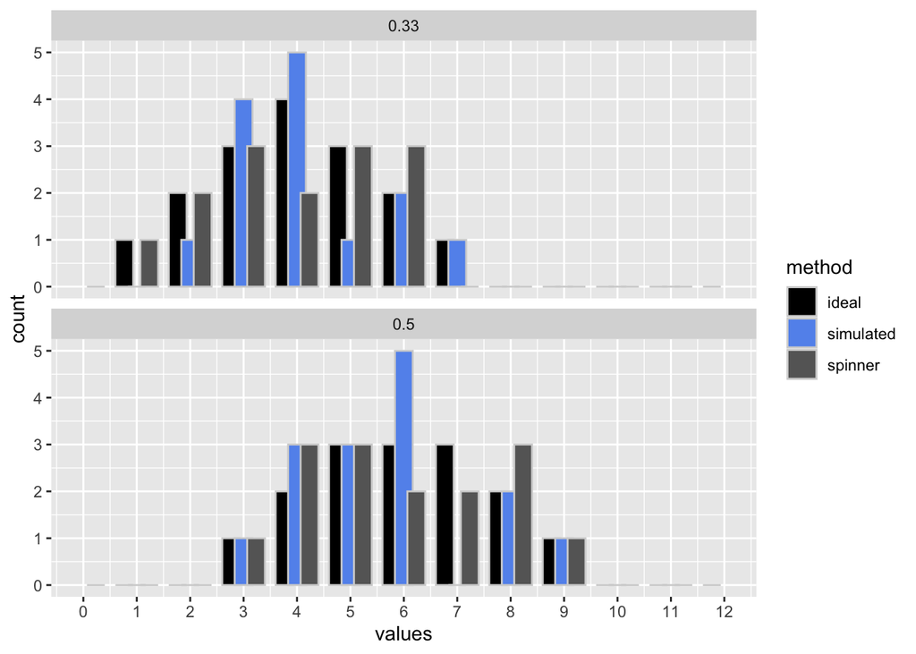

```r
# add to bino_data
new_bino_data <- data.frame("method" = "ideal",
                            "theoretical_probability" = c( rep(0.5, length(ideal0.5) ),
                                                           rep(0.33, length(ideal0.33) ) ),
                            "values" = c( ideal0.5, ideal0.33 ))
bino_data <- rbind(bino_data, new_bino_data)

# plot all frequencies
ggplot(data = bino_data,
       mapping = aes(x = values,
                     fill = method)) +
  geom_histogram(position = position_dodge(0.7),
                 breaks = seq(from = -0.5, to = 12.5, by = 1),
                 col = "lightgrey") +
  scale_fill_manual(values = c("black", "cornflowerblue", "grey40")) +
  scale_x_continuous(breaks = 0:12,
                     labels = 0:12,
                     limits = c(0,12)) +
  facet_wrap(~theoretical_probability,
             ncol = 1)
```

## How likely is each empirical observation in an ideal binomial distribution with given parameters?

We can determine how likely each of the individual observations is given the ideal distribution. We did this earlier in the polio vaccine example. To do this, we can use sister functions of `rbinom()` from the “d/p/q/r” family called `dbinom()` (which we used above) and `pbinom()`. The difference is that `dbinom()` returns the Y value from the PDF (what is the chance of observing exactly the given value?) and `pbinom()` returns the Y value from the CDF (what is the chance of observing the given value or a more extreme value?)

```r
# how likely is it to observe *exactly* 4 successes in 12 trials given the ideal binomial distribution with a 0.5 probability of success?
dbinom(x = 4,
       size = 12,
       prob = 0.5)
```

```
## [1] 0.1208496
```

```r
# *exactly* 8 successes?
dbinom(x = 8,
       size = 12,
       prob = 0.5)
```

```
## [1] 0.1208496
```

```r
# 4 *or fewer* successes?
pbinom(q = 4,
       size = 12,
       prob = 0.5)
```

```
## [1] 0.1938477
```

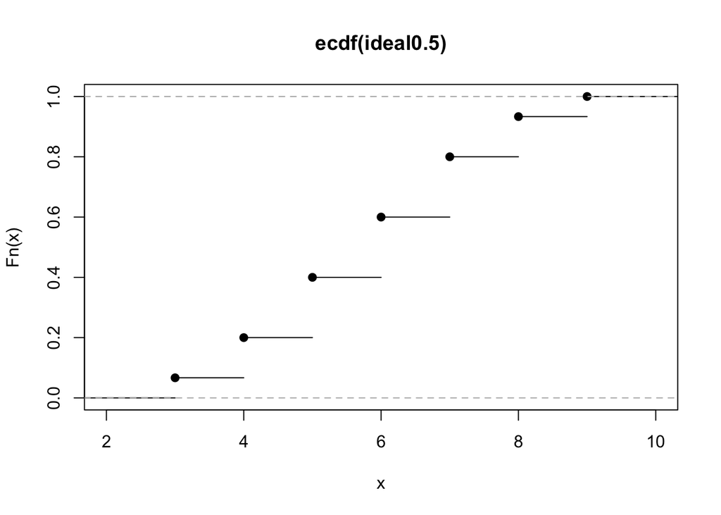

```r
# is it consistent with the eCDF? (note that the values may not match exactly due to rounding)
plot(ecdf(ideal0.5))
```

```r
# 8 *or fewer* successes?
pbinom(q = 8,
       size = 12,
       prob = 0.5)
```

```
## [1] 0.927002
```

```r
# 8 *or more* successes? (i.e. more than 7 successes)
pbinom(q = 7,
       size = 12,
       prob = 0.5,
       lower.tail = FALSE)
```

```
## [1] 0.1938477
```